# Multidimensional Scaling

```r
olive <- read.csv("datasets/olive.csv")
set.seed(123)
N <- sample(1:323, size = 50)
D <- sample(324:421, size = 50)
S <- sample(422:572, size = 50)

acidsamp <- olive[c(N, D, S), 3:10]
```

```r
acidsamp_cmds <- cmdscale(dist(acidsamp), k = 2, eig = TRUE)
acidsamp_cmds
```

```
## $points
##            [,1]        [,2]
## 179  427.219756  -44.268611
## 14  -774.637419  120.458029
## 195  686.795336   -2.781312
## 306 1219.105580 -319.686505
## 118  392.154160 -141.274308
## 299 1089.176977 -323.934324
## 229  506.842424 -208.847004
## 244  484.430420  -93.558750
## 322 1075.800125 -296.656537
## 153  435.665447 -161.163374
## 90   364.873190  -98.666963
## 91   270.373979  -67.905024
## 256  389.098466 -139.379592
```

[output cut: 178 more lines]

We can now plot the observations in the 2 dimensional space.

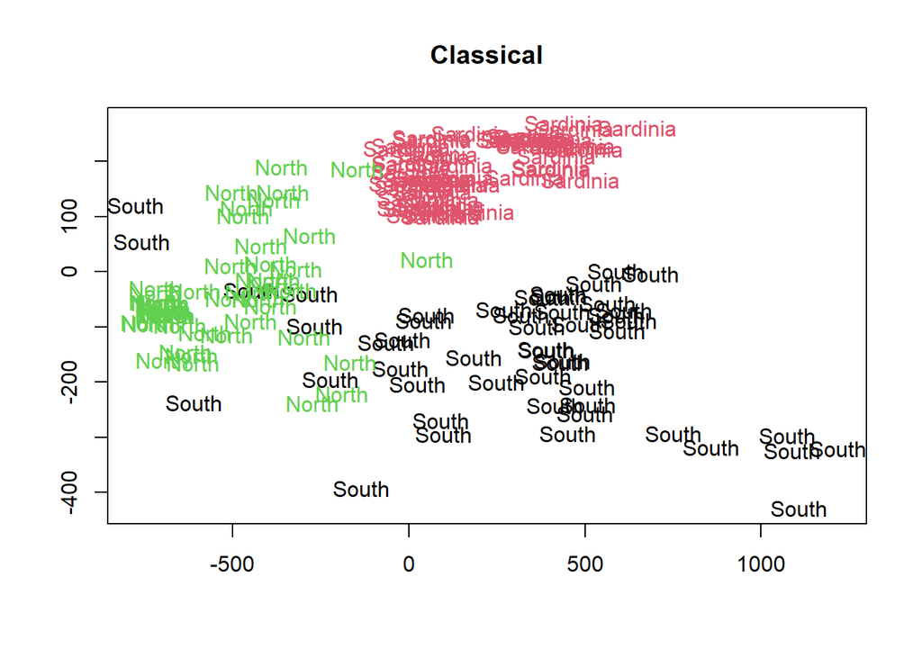

```r
x <- acidsamp_cmds$points[, 1]
y <- acidsamp_cmds$points[, 2]
cols <- c(rep(1, 50), rep(2, 50), rep(3, 50))

plot(x, y, type = "n", xlab = "", ylab = "", main = "Classical")
text(x, y, olive[c(N, D, S), 1], cex = 1, col = cols)
```

## Manual implementation of MDS

Fix $x_1$ at the origin and construct a matrix $B$ such that

$$b_{ij}=-\frac{1}{2}(d_{ij}^2-d_{1i}^2-d_{1j}^2)$$

```r
d <- dist(acidsamp[1:10, ])
d2 <- as.matrix(d^2)
n <- dim(d2)[1]
m <- dim(acidsamp)[2]
B <- matrix(0, nrow = n, ncol = n)
for (i in 1:n) {
  for (j in 1:n) {
    B[i, j] <- -0.5 * (d2[i, j] - d2[i, 1] - d2[j, 1])
  }
}
```

Now compute the eigenvalues and eigenvectors of $B$.

```r
res <- eigen(B)
res$values
```

```
##  [1] 3.235186e+06 1.117165e+05 8.299727e+03 4.867870e+03 8.660542e+02
##  [6] 5.124428e+02 1.719652e+02 2.866762e+01 4.485425e-11 0.000000e+00
```

Calculate new observations of the same dimensionality as the original data.

```r
newdata <- matrix(0, nrow = n, ncol = m)
for (i in 1:n) {
  for (j in 1:m) {
    newdata[i, j] <- sqrt(res$values[j]) * res$vectors[i, j]
  }
}
```

Compare the distance matrices:

```r
sum(dist(newdata))
```

```
## [1] 28863.9
```

```r
sum(dist(acidsamp[1:n, ]))
```

```
## [1] 28863.9
```

### Now do it for $k$ dimensions

Define a function predict for projecting new data into the MDS space.

```r
predict <- function(BMatrix, k) {
  res <- eigen(BMatrix)
  n <- dim(BMatrix)[1]
  prediciton <- matrix(0, nrow = n, ncol = k)
  for (i in 1:n) {
    for (j in 1:k) {
      prediciton[i, j] <- sqrt(res$values[j]) * res$vectors[i, j]
    }
  }
  return(prediciton)
}
```

Run the function for $k=2$.

```r
predict(B, 2)
```

```
##              [,1]       [,2]
##  [1,]    0.000000    0.00000
##  [2,] 1203.811064 -167.58632
##  [3,] -240.640299   95.22897
##  [4,] -837.895678  -58.55267
##  [5,]    7.297074 -108.74612
##  [6,] -720.584408 -126.36960
##  [7,] -122.823548 -144.38341
##  [8,]  -70.031481  -41.73776
##  [9,] -696.525530  -86.19368
## [10,]  -40.184159 -115.41847
```

Do the same with the `cmdscale` function.

```r
cmdscale(dist(acidsamp[1:10, ]), k = 2, eig = TRUE)
```

```
## $points
##            [,1]       [,2]
## 179  -148.67770  -78.26797
## 14  -1358.17277   37.96532
## 195    95.20482 -171.87990
## 306   686.30871   10.70529
## 118  -160.21337   27.39087
## 299   566.34888   68.76667
## 229   -31.44253   71.57468
## 244   -80.41337  -37.88076
## 322   543.99687   33.00112
## 153  -112.93953   38.62468
##
## $eig
##  [1]  3.009384e+06  5.184249e+04  8.147892e+03  3.025409e+03  5.163232e+02
##  [6]  4.298861e+02  1.612138e+02  2.330035e+01  2.820563e-10 -1.557510e-11
##
## $x
## NULL
##
## $ac
## [1] 0
##
## $GOF
## [1] 0.9959968 0.9959968
```

The results are a bit different, but not complete off. We can for example see that the order of the eigenvalues is the same.

```r
res$values
```

```
##  [1] 3.235186e+06 1.117165e+05 8.299727e+03 4.867870e+03 8.660542e+02
##  [6] 5.124428e+02 1.719652e+02 2.866762e+01 4.485425e-11 0.000000e+00
```

Why is this? We need to realize that fi you take any MDS solution and rotate, translate or reflect it, you will get an equivalent solution.

## Procrustes analysis

Procrustes analysis is a technique used to compare two MDS solutions. The goal is to find the best transformation that aligns the two configurations.

```r
library(vegan)
sol1 <- cmdscale(dist(acidsamp[1:10, ]), k = 2, eig = TRUE)
sol2 <- predict(B, 2)
procrustes(sol1$points, sol2, symmetric = TRUE)
```

```
##
## Call:
## procrustes(X = sol1$points, Y = sol2, symmetric = TRUE)
##
## Procrustes sum of squares:
## 2.565e-05
```

The result of a procrustes analysis is the sum of the squared differences between the two configurations. The smaller the value, the better the alignment. We can see that the two configurations are in fact identical.

# Sammon Metric Least Squares & Kruskal Non-Metric Scaling

These two methods are available in the `MASS` package.

```r
library(MASS)
acidsamp_samm <- sammon(dist(acidsamp), k = 2)
```

```
## Initial stress        : 0.00184
## stress after  10 iters: 0.00161, magic = 0.018
## stress after  20 iters: 0.00100, magic = 0.500
## stress after  30 iters: 0.00098, magic = 0.500
```

```r
acidsamp_krus <- isoMDS(dist(acidsamp), k = 2)
```

# t-SNE dimension reduction

t-SNE is a dimension reduction method which uses the idea that the distances between points can be viewed as probabilities. The method tries to minimize the difference between the high-dimensional and low-dimensional probabilities. Similarity between $x_i$ and $x_j$ is defined as the probability that $x_i$ would pick $x_j$ as its neighbor if neighbors were picked in proportion to their probability density under a Gaussian centered at $x_i$. If we denote this probability as $p_{i|j}$, we can see that $p_{i|j} \neq p_{j|i}$. That is why

$$p_{ij} = \frac{p_{i|j} +
p_{j|i}}{2}$$

is used in practice.

The method has a parameter called perplexity which can be viewed as the number of neighbors that should be considered in the high-dimensional space. The method is sensitive to this parameter and it should be fine tuned. Usually the perplexity should be between 5 and 50.

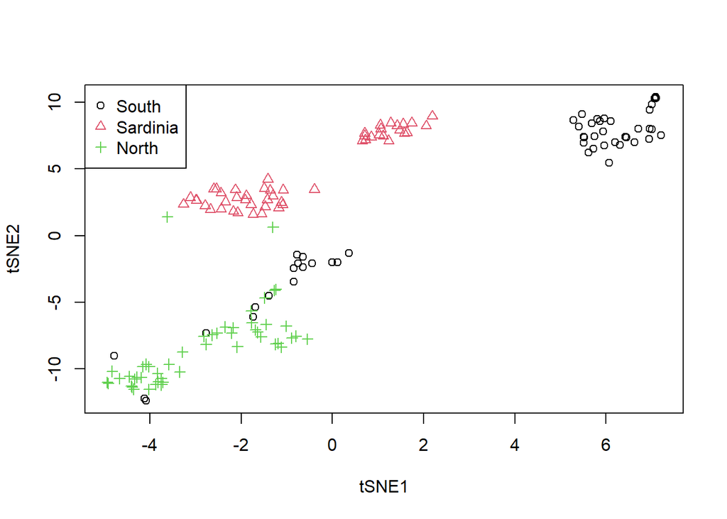

```r
library(Rtsne)

set.seed(123)
acidsamp_tsne <- Rtsne(acidsamp, perplexity = 30)
plot(acidsamp_tsne$Y, col = cols, pch = cols, xlab = "tSNE1", ylab = "tSNE2")
legend("topleft",
  legend = unique(olive[c(N, D, S), 1]),
  col = 1:3, pch = 1:3
)
```

# Compare results

Compare the results of the 4 different methods in a plot.

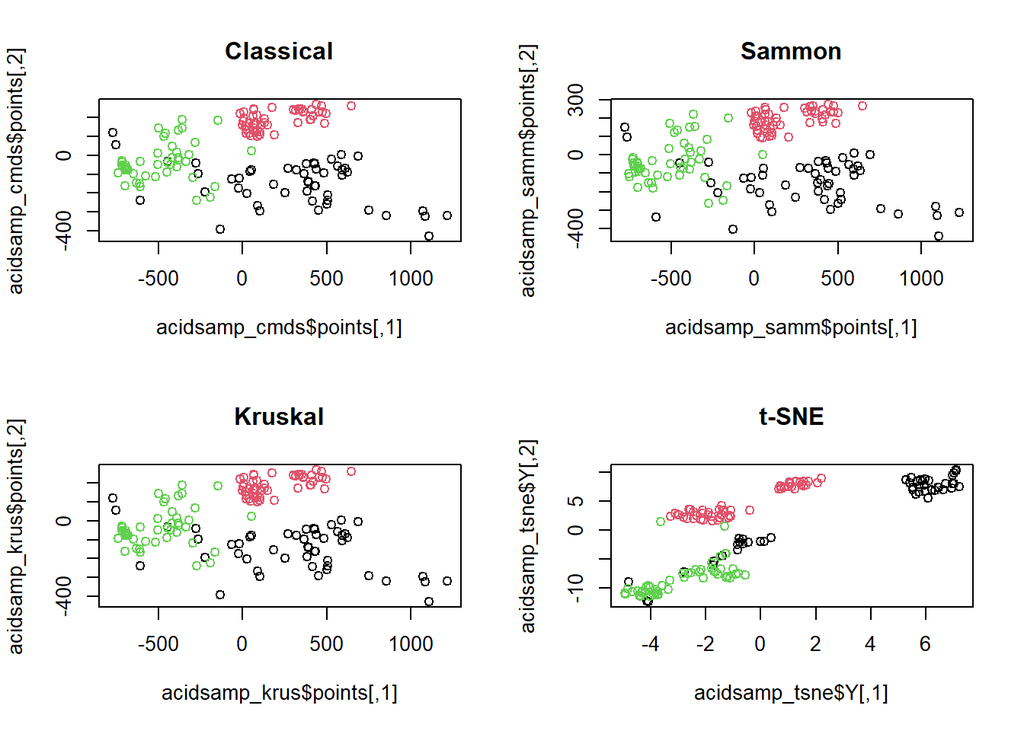

```r
par(mfrow = c(2, 2))
plot(acidsamp_cmds$points, col = cols, main = "Classical")
plot(acidsamp_samm$points, col = cols, main = "Sammon")
plot(acidsamp_krus$points, col = cols, main = "Kruskal")
plot(acidsamp_tsne$Y, col = cols, main = "t-SNE")
```

## Apply Procrustes

Given a target matrix `X` and another matrix `Y`, procrustes will attempt to find the optimal scaling, rotation, and translation of `Y` to make it as similar to `X` as possible. If `symmetric = TRUE`, then procrustes will find the optimal transformation of $\frac{Y}{\sqrt{Y^TY}}$ with respect to the target matrix, $\frac{X}{\sqrt{X^TX}}$.

```r
dimred <- list(
  cmds = acidsamp_cmds$points,
  samm = acidsamp_samm$points,
  krus = acidsamp_krus$points,
  tsne = acidsamp_tsne$Y
)

# SYMMETRIC
proc <- list()
index <- 0
for (i in 1:4) {
  for (j in 1:4) {
    index <- index + 1
    proc[[index]] <- procrustes(X = dimred[[i]], Y = dimred[[j]], symmetric = TRUE)
  }
}
names(proc) <- outer(names(dimred), names(dimred),
  FUN = function(x, y) {
    paste(x, y, sep = "_")
  }
)
round(
  matrix(
    sapply(proc, FUN = function(x) {
      x$ss
    }),
    nrow = 4, byrow = TRUE,
    dimnames = list(names(dimred), names(dimred))
  ),
  digits = 5
)
```

```
##         cmds    samm    krus    tsne
## cmds 0.00000 0.00092 0.00000 0.08907
## samm 0.00092 0.00000 0.00092 0.09657
## krus 0.00000 0.00092 0.00000 0.08907
## tsne 0.08907 0.09657 0.08907 0.00000
```

```r
# ASYMMETRIC
proc2 <- list()
index <- 0
for (i in 1:4) {
  for (j in 1:4) {
    index <- index + 1
    proc2[[index]] <- procrustes(X = dimred[[i]], Y = dimred[[j]], symmetric = FALSE)
  }
}
names(proc2) <- outer(names(dimred), names(dimred),
  FUN = function(x, y) {
    paste(x, y, sep = "_")
  }
)
round(
  matrix(
    sapply(proc2, FUN = function(x) {
      x$ss
    }),
    nrow = 4, byrow = TRUE,
    dimnames = list(names(dimred), names(dimred))
  ),
  digits = 0
)
```

```
##       cmds  samm  krus    tsne
## cmds     0 34108     0 3299411
## samm 34776     0 34774 3647096
## krus     0 34106     0 3299415
## tsne   907   983   907       0
```

### Visualizing Procrustes

Let’s plot the Procrustes errors between classical and Sammon.

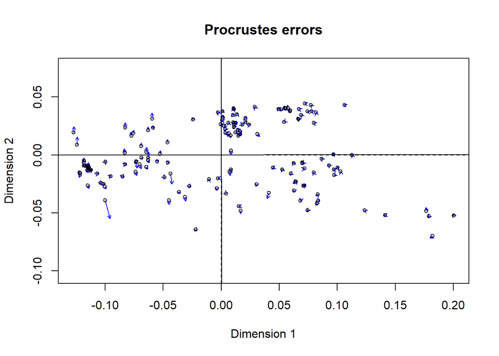

```r
plot(proc$cmds_samm)
```

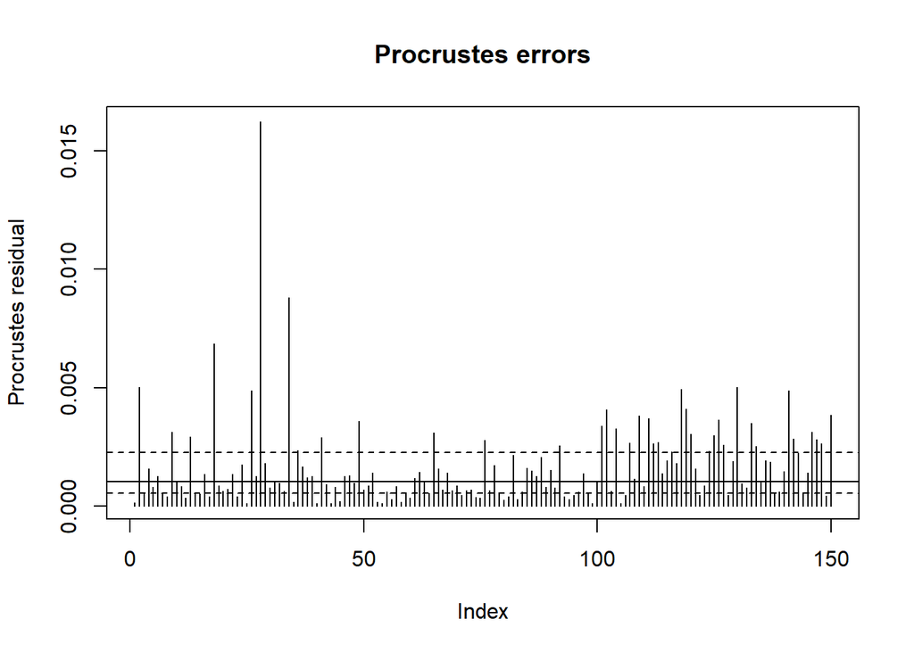

```r
plot(proc$cmds_samm, kind = 2)
```

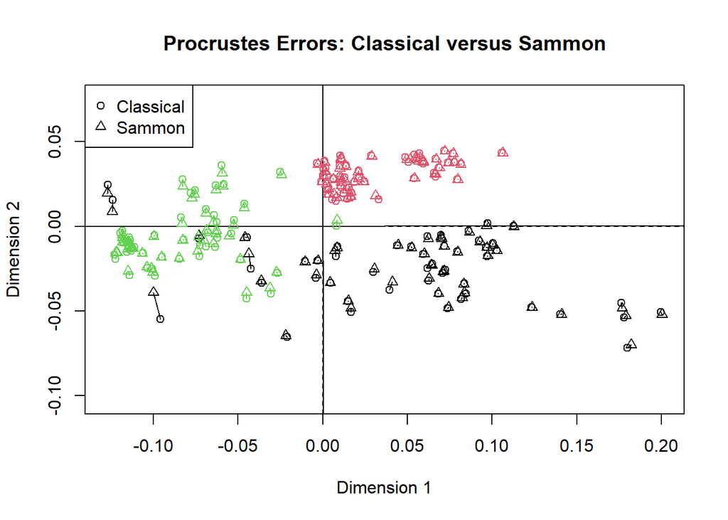

```r
p <- plot(proc$cmds_samm,
  type = "n", to.target = TRUE,
  main = "Procrustes Errors: Classical versus Sammon"
)
points(p$heads, col = cols, pch = 1) # equivalent to points(proc$cmds_samm$X, ...)
points(p$points, col = cols, pch = 2) # equivalent to points(proc$cmds_samm$Yrot, ...)
lines(proc$cmds_samm, type = "segments", col = cols, cex = 0.1)
legend("topleft", legend = c("Classical", "Sammon"), pch = c(1, 2))
```